# Regresní analýza

# Vymazání odlehlých hodnot

## Data před vymazáním

| ticker | min | q1 | median | q3 | max |
| --- | --- | --- | --- | --- | --- |
| AAPL | -0.3492002 | -0.0076602 | 0.0001619 | 0.0042430 | 0.3390972 |
| AMD | -0.6154212 | -0.0107443 | 0.0002435 | 0.0084448 | 0.2967886 |
| AMZN | -0.2262697 | 0.0000482 | 0.0032476 | 0.0112189 | 0.2182972 |
| GOOGL | -0.6033086 | 0.0005516 | 0.0075391 | 0.0214437 | 0.2831292 |
| JNJ | -0.3712162 | 0.0003286 | 0.0033480 | 0.0113573 | 0.2850425 |
| KO | -0.1759941 | 0.0001339 | 0.0021996 | 0.0081062 | 0.1745342 |
| META | -0.4407167 | -0.0032522 | 0.0005077 | 0.0056847 | 0.4305316 |
| MSFT | -0.4926360 | 0.0002480 | 0.0052297 | 0.0168145 | 0.3386330 |
| NFLX | -0.5742996 | 0.0003601 | 0.0043472 | 0.0151613 | 0.5724573 |
| NVDA | -0.2339406 | 0.0000464 | 0.0026085 | 0.0146671 | 0.2200344 |
| PG | -0.1799607 | 0.0001332 | 0.0023467 | 0.0092283 | 0.1678837 |
| TSLA | -0.4065001 | -0.0217130 | -0.0014382 | 0.0021974 | 0.3323695 |
| ^RUT | -0.3326264 | -0.0013374 | 0.0008961 | 0.0054200 | 0.3470238 |
| ^VIX | -0.5460372 | -0.1351076 | -0.0254084 | 0.0117656 | 0.3853825 |
| ^XDA | -0.0802413 | -0.0301906 | -0.0093713 | 0.0043543 | 0.0209063 |
| ^XDB | -0.0057359 | 0.0080747 | 0.0158229 | 0.0237110 | 0.0483671 |
| ^XDE | -0.0387247 | -0.0016271 | 0.0028949 | 0.0103129 | 0.0327996 |
| ^XDN | -0.0369220 | 0.0022448 | 0.0072318 | 0.0177864 | 0.0623513 |

## Proces vymazání

Data se odstraňují tak, aby chyba ocenění byla < 0.15 a aby strip plot ukazoval pouze přihlehlé hodnoty pro každý titul, za účelem vyřazení extrémů. Pro každý titul byla data omezena na hodnoty mezi 4% a 96% kvantilem, mimo tituly:

- Měnové indexy (^XD_), které neomezujeme, jelikož jsou již korektní,
- NFLX, pro který je omezení 8% a 96%, z důvodu velkého počtu extrémních negativních hodnot.
- JNJ a PG, pro které je omezení 6% a 96%, ze stejného důvodu.

Titul ^VIX byl odstraněn kvůli zkreslení modelu kvůli vytváření samostatných clusterů s extrémy.

## Data po vymazání

| ticker | min | q1 | median | q3 | max |
| --- | --- | --- | --- | --- | --- |
| AAPL | -0.0521175 | -0.0058116 | 0.0001830 | 0.0038813 | 0.0426462 |
| AMD | -0.0992216 | -0.0087501 | 0.0002780 | 0.0077929 | 0.0632479 |
| AMZN | -0.0263148 | 0.0001126 | 0.0033769 | 0.0107601 | 0.0353304 |
| GOOGL | -0.0471016 | 0.0008234 | 0.0077778 | 0.0204882 | 0.0767927 |
| JNJ | -0.0225740 | 0.0006401 | 0.0038711 | 0.0112073 | 0.0361114 |
| KO | -0.0322779 | 0.0002744 | 0.0023604 | 0.0075394 | 0.0450329 |
| META | -0.1043029 | -0.0022807 | 0.0005374 | 0.0052504 | 0.0791855 |
| MSFT | -0.1025861 | 0.0004634 | 0.0055254 | 0.0162379 | 0.0472561 |
| NFLX | -0.0861124 | 0.0008571 | 0.0050418 | 0.0150028 | 0.0773141 |
| NVDA | -0.0324870 | 0.0000541 | 0.0027133 | 0.0136054 | 0.0577220 |
| PG | -0.0266188 | 0.0003330 | 0.0025790 | 0.0088838 | 0.0510724 |
| TSLA | -0.0702260 | -0.0195423 | -0.0012483 | 0.0018736 | 0.0621604 |
| ^RUT | -0.0631446 | -0.0006373 | 0.0009368 | 0.0050719 | 0.0265446 |
| ^XDA | -0.0802413 | -0.0301906 | -0.0093713 | 0.0043543 | 0.0209063 |
| ^XDB | -0.0057359 | 0.0080747 | 0.0158229 | 0.0237110 | 0.0483671 |
| ^XDE | -0.0387247 | -0.0016271 | 0.0028949 | 0.0103129 | 0.0327996 |
| ^XDN | -0.0369220 | 0.0022448 | 0.0072318 | 0.0177864 | 0.0623513 |

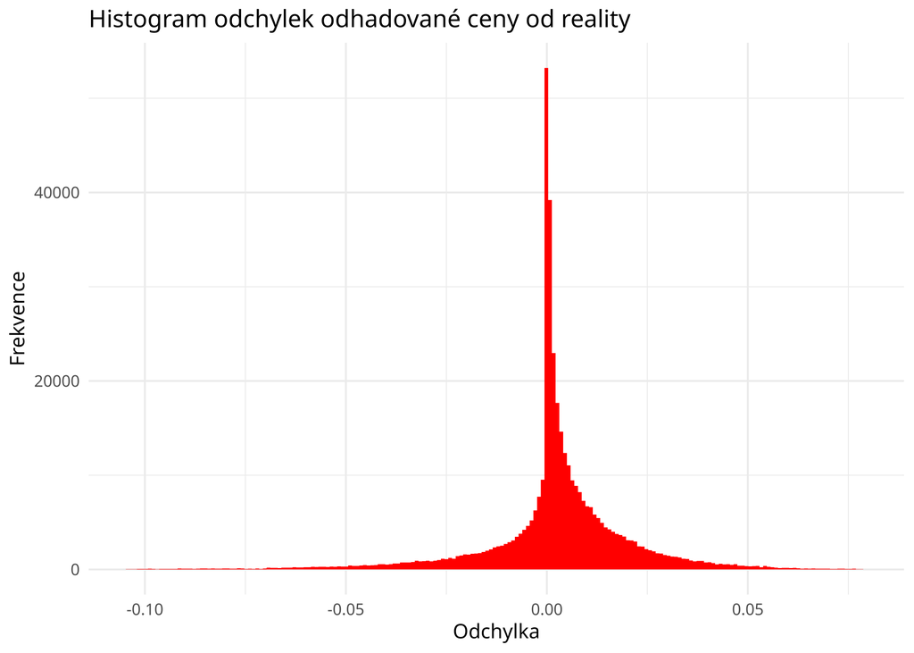

## LMER model - fixní ticker

```r
subset_args <- c(
  "S",
  #"moneyness",
  "K",
  "r",
  "sigma",
  "q",
  "T",
  "am_eu",
  "call_put",
  "model",
  "ticker"
  )
interactions <- c(
  #"(1 | ticker)",
  "(1 | snapshot_month)"
)

rhs <- paste(c(subset_args, interactions), collapse = " + ")
formula <- as.formula(paste("pricing_error ~ ", rhs))

rmr_relative <- lmer(formula, data = train_data_rel)
```

```
## fixed-effect model matrix is rank deficient so dropping 1 column / coefficient
```

```r
summary(rmr_relative)
```

```
## Linear mixed model fit by REML. t-tests use Satterthwaite's method [
## lmerModLmerTest]
## Formula: formula
##    Data: train_data_rel
##
## REML criterion at convergence: -1767932
##
## Scaled residuals:
##     Min      1Q  Median      3Q     Max
## -6.9921 -0.3328  0.0644  0.4432  5.1756
##
## Random effects:
##  Groups         Name        Variance  Std.Dev.
##  snapshot_month (Intercept) 5.411e-07 0.0007356
##  Residual                   2.735e-04 0.0165364
## Number of obs: 329512, groups:  snapshot_month, 4
##
## Fixed effects:
##                 Estimate Std. Error         df t value Pr(>|t|)
## (Intercept)   -3.064e-02  1.331e-03  4.981e+02 -23.021  < 2e-16 ***
## S              1.227e-05  5.997e-07  8.834e+04  20.468  < 2e-16 ***
## K             -7.470e-06  1.388e-07  3.295e+05 -53.814  < 2e-16 ***
## r              1.759e+00  2.842e-02  1.484e+05  61.878  < 2e-16 ***
## sigma         -8.035e-02  1.254e-03  6.284e+04 -64.094  < 2e-16 ***
## q             -4.427e-01  4.958e-02  3.294e+05  -8.928  < 2e-16 ***
## T              3.878e-03  4.148e-05  3.294e+05  93.488  < 2e-16 ***
## am_eueuropean -3.007e-02  1.493e-03  5.079e+04 -20.135  < 2e-16 ***
## call_putputs  -3.106e-03  6.019e-05  3.295e+05 -51.603  < 2e-16 ***
## modeluser_crr  7.334e-05  7.056e-05  3.295e+05   1.039  0.29868
## modeluser_mc   1.111e-05  7.056e-05  3.295e+05   0.157  0.87495
## ticker^XDA    -1.272e-02  2.372e-03  2.428e+05  -5.362 8.23e-08 ***
## ticker^XDB     1.740e-02  2.131e-03  2.283e+05   8.164 3.25e-16 ***
## ticker^XDE     4.389e-03  1.900e-03  1.908e+05   2.309  0.02092 *
## ticker^XDN     1.198e-02  2.025e-03  1.951e+05   5.918 3.27e-09 ***
## tickerAAPL    -1.371e-02  4.219e-04  1.830e+05 -32.501  < 2e-16 ***
## tickerAMD      1.068e-02  1.745e-04  1.141e+05  61.196  < 2e-16 ***
## tickerAMZN    -4.464e-03  3.211e-04  1.890e+05 -13.902  < 2e-16 ***
## tickerGOOGL    8.130e-04  4.066e-04  1.646e+05   1.999  0.04557 *
## tickerJNJ     -2.362e-04  1.739e-03  3.242e+05  -0.136  0.89196
## tickerKO      -4.710e-03  1.584e-03  3.249e+05  -2.974  0.00294 **
## tickerMETA    -7.875e-03  3.442e-04  7.032e+04 -22.879  < 2e-16 ***
## tickerMSFT    -7.114e-03  5.703e-04  1.667e+05 -12.473  < 2e-16 ***
## tickerNFLX    -1.672e-03  3.392e-04  2.582e+05  -4.927 8.34e-07 ***
## tickerNVDA     3.710e-03  2.446e-04  2.887e+05  15.169  < 2e-16 ***
## tickerPG      -3.486e-03  1.436e-03  3.226e+05  -2.427  0.01522 *
## ---
## Signif. codes:  0 '***' 0.001 '**' 0.01 '*' 0.05 '.' 0.1 ' ' 1
```

```
##
## Correlation matrix not shown by default, as p = 26 > 12.
## Use print(x, correlation=TRUE)  or
##     vcov(x)        if you need it
```

```
## fit warnings:
## fixed-effect model matrix is rank deficient so dropping 1 column / coefficient
## Some predictor variables are on very different scales: consider rescaling.
## You may also use (g)lmerControl(autoscale = TRUE) to improve numerical stability.
```

```r
r2(rmr_relative)
```

```
## Random effect variances not available. Returned R2 does not account for random effects.
```

```
## # R2 for Mixed Models
##
##   Conditional R2: NA
##      Marginal R2: 0.176
```

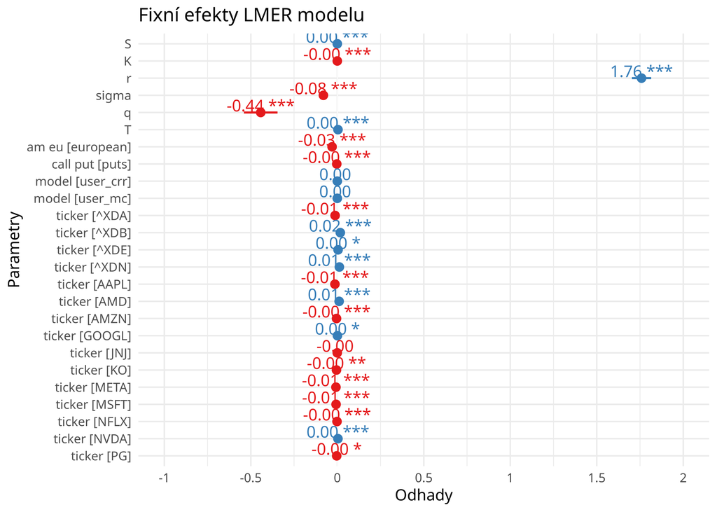

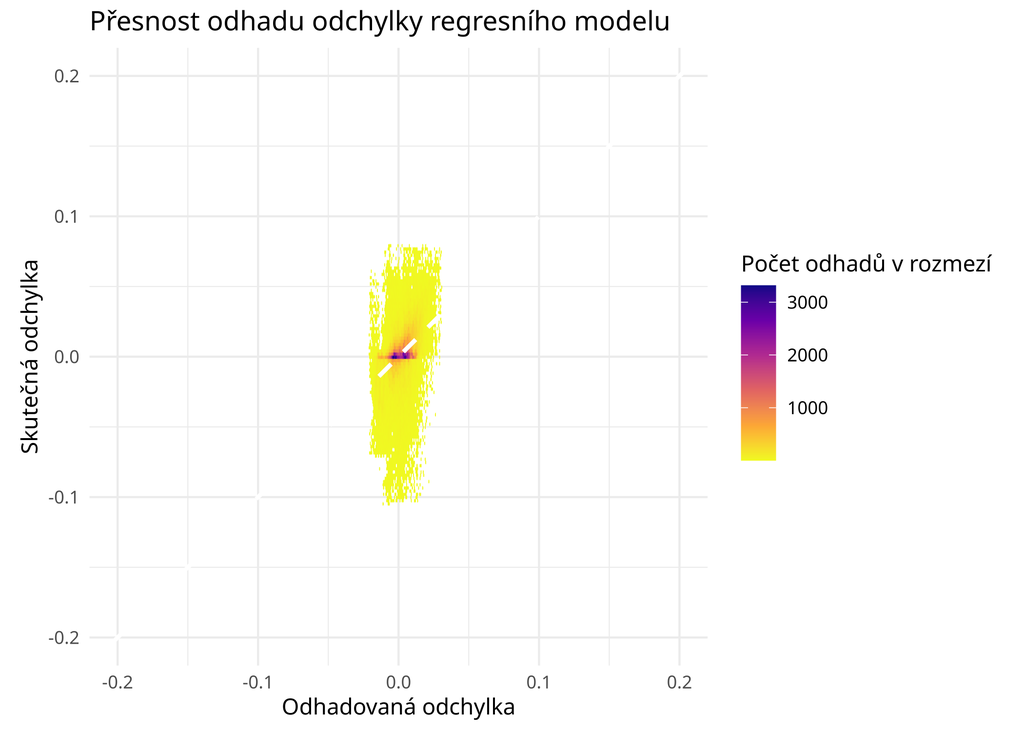

```r
anova(rmr_relative)
```

```
## Type III Analysis of Variance Table with Satterthwaite's method
##          Sum Sq Mean Sq NumDF  DenDF   F value Pr(>F)
## S        0.1146 0.11456     1  88338  418.9509 <2e-16 ***
## K        0.7919 0.79191     1 329482 2895.9600 <2e-16 ***
## r        1.0470 1.04703     1 148392 3828.9298 <2e-16 ***
## sigma    1.1234 1.12336     1  62842 4108.0474 <2e-16 ***
## q        0.0218 0.02180     1 329375   79.7133 <2e-16 ***
## T        2.3900 2.39001     1 329404 8740.0863 <2e-16 ***
## am_eu    0.1109 0.11087     1  50790  405.4319 <2e-16 ***
## call_put 0.7282 0.72818     1 329483 2662.9111 <2e-16 ***
## model    0.0003 0.00017     2 329483    0.6275 0.5339
## ticker   4.7077 0.31385    15 267043 1147.7217 <2e-16 ***
## ---
## Signif. codes:  0 '***' 0.001 '**' 0.01 '*' 0.05 '.' 0.1 ' ' 1
```

```r
ranef(rmr_relative)
```

```
## $snapshot_month
##      (Intercept)
## 01 -7.732076e-04
## 02  9.846624e-04
## 03 -1.525591e-05
## 05 -1.961989e-04
##
## with conditional variances for "snapshot_month"
```

## LMER model - náhodný ticker

```r
subset_args <- c(
  #"S",
  "moneyness",
  "K",
  "r",
  "sigma",
  "q",
  "T",
  "am_eu",
  "call_put",
  "model"
  #"ticker"
)
interactions <- c(
  "(1 | ticker)",
  "(1 | snapshot_month)"
)

rhs <- paste(c(subset_args, interactions), collapse = " + ")
formula <- as.formula(paste("pricing_error ~ ", rhs))

rmr_relative <- lmer(formula, data = train_data_rel)
summary(rmr_relative)
```

```
## Linear mixed model fit by REML. t-tests use Satterthwaite's method [
## lmerModLmerTest]
## Formula: formula
##    Data: train_data_rel
##
## REML criterion at convergence: -1767629
##
## Scaled residuals:
##     Min      1Q  Median      3Q     Max
## -7.0204 -0.3318  0.0616  0.4436  5.1970
##
## Random effects:
##  Groups         Name        Variance  Std.Dev.
##  ticker         (Intercept) 8.793e-05 0.0093772
##  snapshot_month (Intercept) 6.748e-07 0.0008215
##  Residual                   2.738e-04 0.0165466
## Number of obs: 329512, groups:  ticker, 17; snapshot_month, 4
##
## Fixed effects:
##                 Estimate Std. Error         df t value Pr(>|t|)
## (Intercept)   -3.017e-02  3.000e-03  2.180e+01 -10.056  1.2e-09 ***
## moneyness      1.276e-04  3.298e-05  3.284e+05   3.868  0.00011 ***
## K             -6.762e-06  1.588e-07  3.156e+05 -42.584  < 2e-16 ***
## r              1.744e+00  2.844e-02  1.866e+05  61.305  < 2e-16 ***
## sigma         -7.601e-02  1.236e-03  1.103e+05 -61.519  < 2e-16 ***
## q             -5.160e-01  4.825e-02  5.922e+03 -10.695  < 2e-16 ***
## T              3.856e-03  4.172e-05  3.295e+05  92.429  < 2e-16 ***
## am_eueuropean -1.914e-02  5.056e-03  1.525e+01  -3.787  0.00174 **
## call_putputs  -3.070e-03  6.023e-05  3.295e+05 -50.973  < 2e-16 ***
## modeluser_crr  7.301e-05  7.061e-05  3.295e+05   1.034  0.30112
## modeluser_mc   1.172e-05  7.061e-05  3.295e+05   0.166  0.86819
## ---
## Signif. codes:  0 '***' 0.001 '**' 0.01 '*' 0.05 '.' 0.1 ' ' 1
##
## Correlation of Fixed Effects:
##             (Intr) mnynss K      r      sigma  q      T      am_rpn cll_pt
## moneyness   -0.021
## K           -0.017  0.500
## r           -0.350  0.020  0.008
## sigma       -0.144 -0.056 -0.068  0.000
## q           -0.150  0.011  0.005 -0.024  0.049
## T           -0.060 -0.102 -0.075  0.156 -0.009  0.001
## am_eueuropn -0.504 -0.005 -0.012 -0.002  0.060  0.093  0.003
## call_putpts -0.006 -0.038  0.211 -0.011 -0.014 -0.001 -0.018 -0.002
## modelsr_crr -0.012  0.001  0.002  0.000  0.000  0.001 -0.001  0.000  0.000
## modelusr_mc -0.011 -0.001  0.001 -0.001  0.001  0.001  0.000  0.000 -0.001
##             mdlsr_c
## moneyness
## K
## r
## sigma
## q
## T
## am_eueuropn
## call_putpts
## modelsr_crr
## modelusr_mc  0.500
## fit warnings:
## Some predictor variables are on very different scales: consider rescaling.
## You may also use (g)lmerControl(autoscale = TRUE) to improve numerical stability.
```

```r
r2(rmr_relative)
```

```
## Random effect variances not available. Returned R2 does not account for random effects.
```

```
## # R2 for Mixed Models
##
##   Conditional R2: NA
##      Marginal R2: 0.316
```

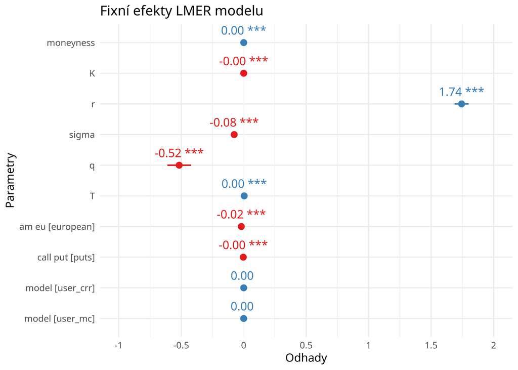

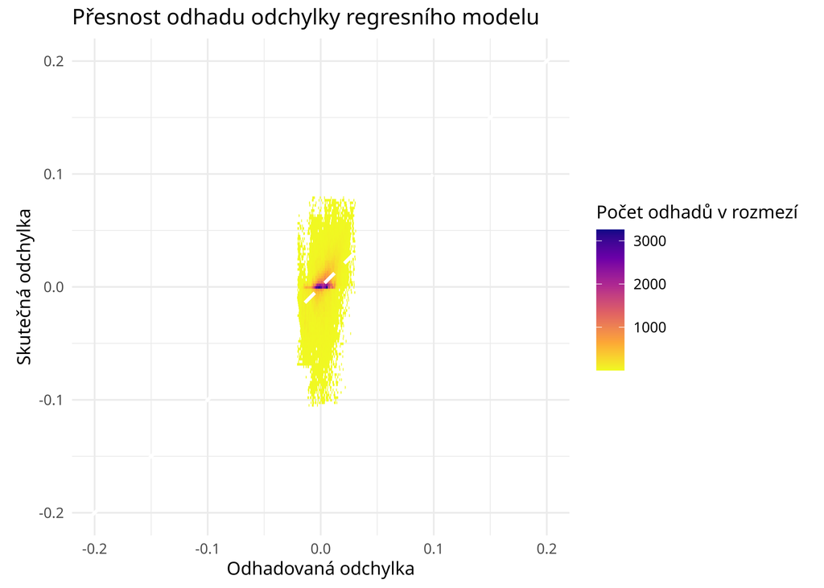

```r
anova(rmr_relative)
```

```
## Type III Analysis of Variance Table with Satterthwaite's method
##            Sum Sq Mean Sq NumDF  DenDF   F value    Pr(>F)
## moneyness 0.00410 0.00410     1 328420   14.9614 0.0001098 ***
## K         0.49649 0.49649     1 315558 1813.4241 < 2.2e-16 ***
## r         1.02897 1.02897     1 186587 3758.2713 < 2.2e-16 ***
## sigma     1.03616 1.03616     1 110323 3784.5268 < 2.2e-16 ***
## q         0.03132 0.03132     1   5922  114.3768 < 2.2e-16 ***
## T         2.33899 2.33899     1 329452 8543.0642 < 2.2e-16 ***
## am_eu     0.00393 0.00393     1     15   14.3400 0.0017441 **
## call_put  0.71136 0.71136     1 329478 2598.2014 < 2.2e-16 ***
## model     0.00034 0.00017     2 329483    0.6168 0.5396870
## ---
## Signif. codes:  0 '***' 0.001 '**' 0.01 '*' 0.05 '.' 0.1 ' ' 1
```

```r
ranef(rmr_relative)
```

```
## $ticker
##         (Intercept)
## ^RUT   0.0191713016
## ^XDA  -0.0224685466
## ^XDB   0.0074723349
## ^XDE  -0.0054279112
## ^XDN   0.0012528218
## AAPL  -0.0115788662
## AMD    0.0113429224
## AMZN  -0.0033178243
## GOOGL  0.0035135559
## JNJ    0.0040969623
## KO    -0.0023674860
## META  -0.0022403252
## MSFT  -0.0029002792
## NFLX  -0.0021610026
## NVDA   0.0040091255
## PG    -0.0006263691
## TSLA   0.0022295884
##
## $snapshot_month
##      (Intercept)
## 01 -0.0007275627
## 02  0.0008290642
## 03 -0.0006784319
## 05  0.0005769304
##
## with conditional variances for "ticker" "snapshot_month"
```

## LMER model - náhodný ticker (fixní efekt měsíce sběru)

Stejné významnosti jako model s náhodným efektem měsíce, menší mezní $R^2$ než u předchozího modelu, podmíněné $R^2$ je větší než mezní $R^2$ předchozího modelu.

```r
subset_args <- c(
  #"S",
  "moneyness",
  "K",
  "r",
  "sigma",
  "q",
  "T",
  "am_eu",
  "call_put",
  "snapshot_month",
  "model"
  #"ticker"
)
interactions <- c(
  "(1 | ticker)"
  #"(1 | snapshot_month)"
)

rhs <- paste(c(subset_args, interactions), collapse = " + ")
formula <- as.formula(paste("pricing_error ~ ", rhs))

rmr_relative <- lmer(formula, data = train_data_rel)
summary(rmr_relative)
```

```
## Linear mixed model fit by REML. t-tests use Satterthwaite's method [
## lmerModLmerTest]
## Formula: formula
##    Data: train_data_rel
##
## REML criterion at convergence: -1767596
##
## Scaled residuals:
##     Min      1Q  Median      3Q     Max
## -7.0207 -0.3319  0.0616  0.4436  5.1968
##
## Random effects:
##  Groups   Name        Variance  Std.Dev.
##  ticker   (Intercept) 0.0000879 0.009375
##  Residual             0.0002738 0.016547
## Number of obs: 329512, groups:  ticker, 17
##
## Fixed effects:
##                    Estimate Std. Error         df t value Pr(>|t|)
## (Intercept)      -3.094e-02  2.972e-03  2.104e+01 -10.414 9.29e-10 ***
## moneyness         1.273e-04  3.298e-05  3.289e+05   3.860 0.000114 ***
## K                -6.764e-06  1.588e-07  3.167e+05 -42.592  < 2e-16 ***
## r                 1.744e+00  2.848e-02  3.295e+05  61.242  < 2e-16 ***
## sigma            -7.596e-02  1.238e-03  2.678e+05 -61.353  < 2e-16 ***
## q                -5.155e-01  4.825e-02  5.919e+03 -10.685  < 2e-16 ***
## T                 3.856e-03  4.172e-05  3.295e+05  92.434  < 2e-16 ***
## am_eueuropean    -1.913e-02  5.055e-03  1.525e+01  -3.784 0.001753 **
## call_putputs     -3.070e-03  6.023e-05  3.295e+05 -50.975  < 2e-16 ***
## snapshot_month02  1.565e-03  8.401e-05  3.290e+05  18.625  < 2e-16 ***
## snapshot_month03  4.919e-05  8.906e-05  3.295e+05   0.552 0.580755
## snapshot_month05  1.313e-03  1.088e-04  3.252e+05  12.063  < 2e-16 ***
## modeluser_crr     7.301e-05  7.061e-05  3.295e+05   1.034 0.301105
## modeluser_mc      1.172e-05  7.061e-05  3.295e+05   0.166 0.868191
## ---
## Signif. codes:  0 '***' 0.001 '**' 0.01 '*' 0.05 '.' 0.1 ' ' 1
```

```
##
## Correlation matrix not shown by default, as p = 14 > 12.
## Use print(x, correlation=TRUE)  or
##     vcov(x)        if you need it
```

```
## fit warnings:
## Some predictor variables are on very different scales: consider rescaling.
## You may also use (g)lmerControl(autoscale = TRUE) to improve numerical stability.
```

```r
r2(rmr_relative)
```

```
## # R2 for Mixed Models
##
##   Conditional R2: 0.440
##      Marginal R2: 0.261
```

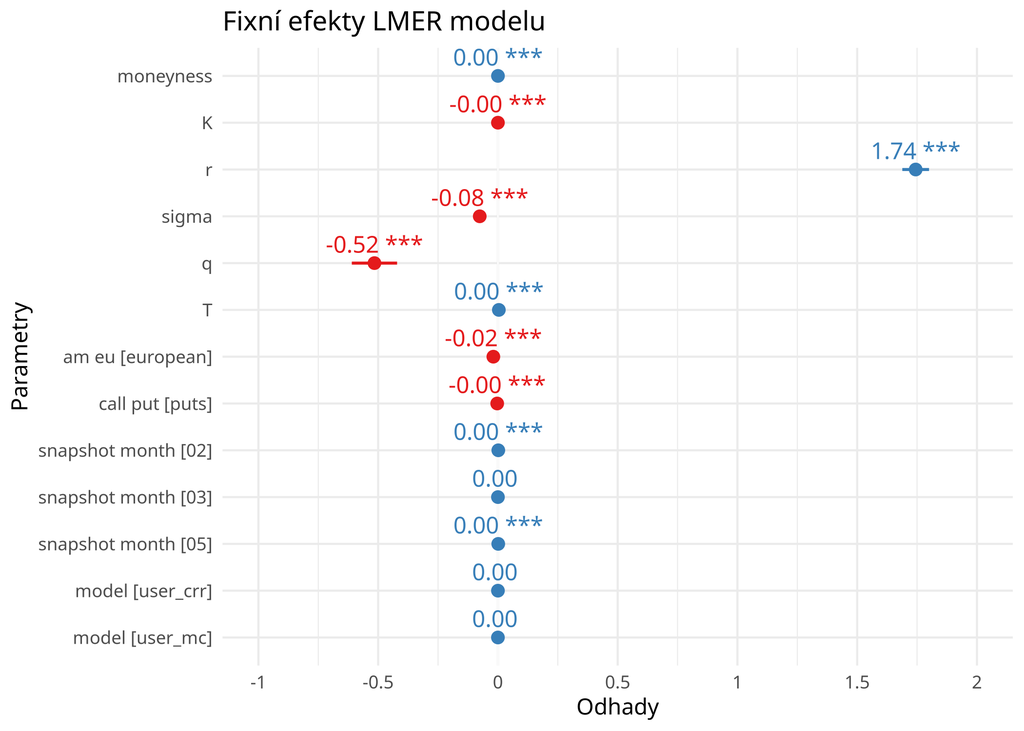

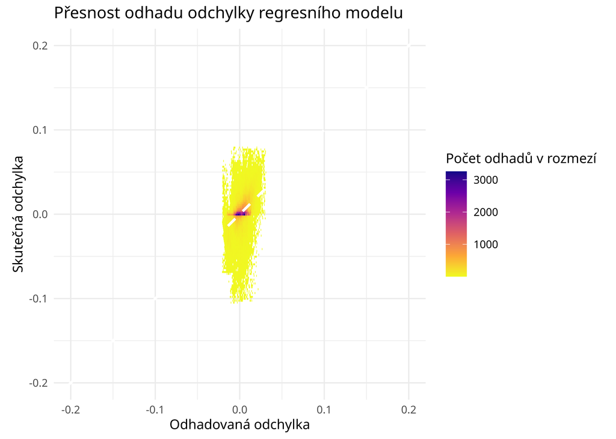

```r
anova(rmr_relative)
```

```
## Type III Analysis of Variance Table with Satterthwaite's method
##                 Sum Sq Mean Sq NumDF  DenDF   F value    Pr(>F)
## moneyness      0.00408 0.00408     1 328850   14.8972 0.0001136 ***
## K              0.49666 0.49666     1 316683 1814.0385 < 2.2e-16 ***
## r              1.02687 1.02687     1 329496 3750.5849 < 2.2e-16 ***
## sigma          1.03059 1.03059     1 267831 3764.1725 < 2.2e-16 ***
## q              0.03126 0.03126     1   5919  114.1619 < 2.2e-16 ***
## T              2.33925 2.33925     1 329490 8544.0021 < 2.2e-16 ***
## am_eu          0.00392 0.00392     1     15   14.3199 0.0017532 **
## call_put       0.71141 0.71141     1 329476 2598.4085 < 2.2e-16 ***
## snapshot_month 0.14574 0.04858     3 326904  177.4389 < 2.2e-16 ***
## model          0.00034 0.00017     2 329483    0.6168 0.5396717
## ---
## Signif. codes:  0 '***' 0.001 '**' 0.01 '*' 0.05 '.' 0.1 ' ' 1
```

```r
ranef(rmr_relative)
```

```
## $ticker
##         (Intercept)
## ^RUT   0.0191694048
## ^XDA  -0.0224690629
## ^XDB   0.0074741412
## ^XDE  -0.0054268455
## ^XDN   0.0012523622
## AAPL  -0.0115743728
## AMD    0.0113320160
## AMZN  -0.0033133621
## GOOGL  0.0035173880
## JNJ    0.0040930037
## KO    -0.0023691319
## META  -0.0022388972
## MSFT  -0.0028951356
## NFLX  -0.0021563317
## NVDA   0.0040094309
## PG    -0.0006273353
## TSLA   0.0022227269
##
## with conditional variances for "ticker"
```

## LMER model - náhodný ticker (žádný efekt měsíce)

```r
subset_args <- c(
  #"S",
  "moneyness",
  "K",
  "r",
  "sigma",
  "q",
  "T",
  "am_eu",
  "call_put",
  "model"
  #"ticker"
)
interactions <- c(
  "(1 | ticker)"
  #"(1 | snapshot_month)"
)

rhs <- paste(c(subset_args, interactions), collapse = " + ")
formula <- as.formula(paste("pricing_error ~ ", rhs))

rmr_relative <- lmer(formula, data = train_data_rel)
summary(rmr_relative)
```

```
## Linear mixed model fit by REML. t-tests use Satterthwaite's method [
## lmerModLmerTest]
## Formula: formula
##    Data: train_data_rel
##
## REML criterion at convergence: -1767115
##
## Scaled residuals:
##     Min      1Q  Median      3Q     Max
## -6.9710 -0.3312  0.0582  0.4379  5.2392
##
## Random effects:
##  Groups   Name        Variance  Std.Dev.
##  ticker   (Intercept) 9.291e-05 0.009639
##  Residual             2.742e-04 0.016560
## Number of obs: 329512, groups:  ticker, 17
##
## Fixed effects:
##                 Estimate Std. Error         df t value Pr(>|t|)
## (Intercept)   -2.252e-02  3.007e-03  1.982e+01  -7.490 3.37e-07 ***
## moneyness      1.645e-04  3.276e-05  3.289e+05   5.023 5.10e-07 ***
## K             -6.503e-06  1.571e-07  3.166e+05 -41.390  < 2e-16 ***
## r              1.624e+00  2.415e-02  3.285e+05  67.240  < 2e-16 ***
## sigma         -8.337e-02  9.600e-04  3.031e+05 -86.841  < 2e-16 ***
## q             -6.016e-01  4.816e-02  6.539e+03 -12.492  < 2e-16 ***
## T              3.802e-03  4.162e-05  3.295e+05  91.334  < 2e-16 ***
## am_eueuropean -2.165e-02  5.189e-03  1.522e+01  -4.171 0.000795 ***
## call_putputs  -3.050e-03  6.026e-05  3.295e+05 -50.620  < 2e-16 ***
## modeluser_crr  7.277e-05  7.066e-05  3.295e+05   1.030 0.303083
## modeluser_mc   1.198e-05  7.066e-05  3.295e+05   0.170 0.865339
## ---
## Signif. codes:  0 '***' 0.001 '**' 0.01 '*' 0.05 '.' 0.1 ' ' 1
##
## Correlation of Fixed Effects:
##             (Intr) mnynss K      r      sigma  q      T      am_rpn cll_pt
## moneyness   -0.024
## K           -0.020  0.491
## r           -0.328  0.002 -0.022
## sigma       -0.206  0.014  0.024  0.313
## q           -0.146  0.013  0.009 -0.029  0.031
## T           -0.048 -0.101 -0.074  0.143 -0.004 -0.002
## am_eueuropn -0.518 -0.001 -0.007  0.011  0.044  0.089  0.003
## call_putpts -0.007 -0.041  0.210 -0.014 -0.002  0.000 -0.017 -0.002
## modelsr_crr -0.012  0.001  0.002  0.000 -0.001  0.001 -0.001  0.000  0.000
## modelusr_mc -0.012 -0.001  0.001 -0.001  0.000  0.001  0.000  0.000 -0.001
##             mdlsr_c
## moneyness
## K
## r
## sigma
## q
## T
## am_eueuropn
## call_putpts
## modelsr_crr
## modelusr_mc  0.500
## fit warnings:
## Some predictor variables are on very different scales: consider rescaling.
## You may also use (g)lmerControl(autoscale = TRUE) to improve numerical stability.
```

```r
r2(rmr_relative)
```

```
## # R2 for Mixed Models
##
##   Conditional R2: 0.458
##      Marginal R2: 0.275
```

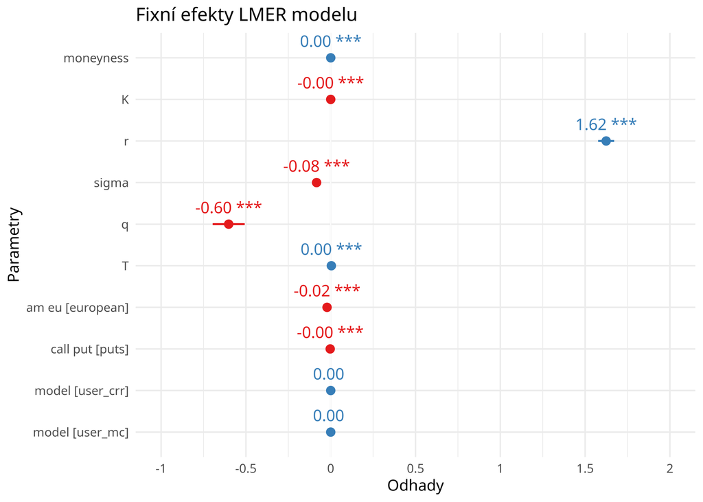

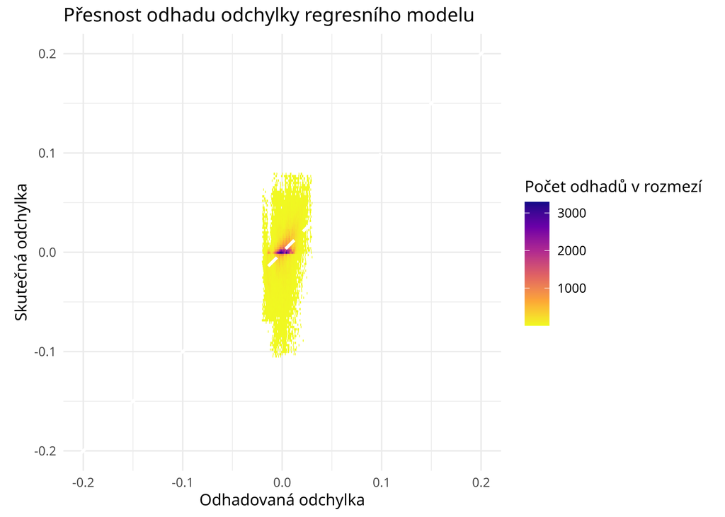

```r
anova(rmr_relative)
```

```
## Type III Analysis of Variance Table with Satterthwaite's method
##            Sum Sq Mean Sq NumDF  DenDF   F value    Pr(>F)
## moneyness 0.00692 0.00692     1 328862   25.2264 5.101e-07 ***
## K         0.46978 0.46978     1 316591 1713.1088 < 2.2e-16 ***
## r         1.23986 1.23986     1 328492 4521.2840 < 2.2e-16 ***
## sigma     2.06806 2.06806     1 303128 7541.4114 < 2.2e-16 ***
## q         0.04280 0.04280     1   6539  156.0610 < 2.2e-16 ***
## T         2.28756 2.28756     1 329493 8341.8387 < 2.2e-16 ***
## am_eu     0.00477 0.00477     1     15   17.3987 0.0007952 ***
## call_put  0.70268 0.70268     1 329482 2562.4044 < 2.2e-16 ***
## model     0.00033 0.00017     2 329486    0.6098 0.5434736
## ---
## Signif. codes:  0 '***' 0.001 '**' 0.01 '*' 0.05 '.' 0.1 ' ' 1
```

```r
ranef(rmr_relative)
```

```
## $ticker
##         (Intercept)
## ^RUT   0.0194164438
## ^XDA  -0.0223781023
## ^XDB   0.0072032003
## ^XDE  -0.0055657220
## ^XDN   0.0013241805
## AAPL  -0.0122954136
## AMD    0.0127155553
## AMZN  -0.0041191952
## GOOGL  0.0028885162
## JNJ    0.0051015232
## KO    -0.0017503016
## META  -0.0025509177
## MSFT  -0.0036452854
## NFLX  -0.0030000844
## NVDA   0.0037972372
## PG    -0.0001685271
## TSLA   0.0030268930
##
## with conditional variances for "ticker"
```